# Homework 05

Set a random seed before each simulation question and report it. You may use standard packages unless a question asks you to write the calculation yourself. Use equal neighbor weights throughout. Here $p$ counts the covariates used to measure distance; do not add an intercept column to a KNN predictor matrix. R and Python use different random-number generators, so their exact simulation results need not agree.

## Question 1: Estimate the bias and variance of KNN

In our previous homework, we used repeated simulations to study the behavior of linear regression estimators. We will now use the same idea for KNN. Consider the regression model

$$Y_i=f(\mathbf X_i)+\epsilon_i,
\qquad
f(\mathbf x)=0.5x_1+\sin(x_2)-0.3x_3^2,$$

where the three covariates are independent standard normal variables and $\epsilon_i\sim\mathcal N(0,0.1^2)$ independently of the covariates and other observations. Generate $n=400$ training observations. Our goal is to estimate the mean response at

$$\mathbf x_0=(0.5,0.7,1)^{\mathsf T}.$$

Use Euclidean distance and consider $k=1,3,5,\ldots,29$.

1. Calculate $f(\mathbf x_0)$. Generate one training dataset and obtain the KNN prediction at $\mathbf x_0$ for each value of $k$.

**Answer 1a.** The true mean response at $\mathbf x_0$ is

$$f(\mathbf x_0)=0.5(0.5)+\sin(0.7)-0.3(1)^2=0.25+0.644218-0.3\approx 0.594218.$$

I used seed `432` (NumPy `default_rng`) for Question 1. The KNN prediction is the plain average of the $k$ nearest training responses in Euclidean distance on $(X_1,X_2,X_3)$, with no intercept column in the predictor matrix.

**Show the workflow**

```python
import numpy as np
import pandas as pd
import matplotlib.pyplot as plt

def f_true(X):
    return 0.5 * X[:, 0] + np.sin(X[:, 1]) - 0.3 * X[:, 2]**2

q1_rng = np.random.default_rng(432)
q1_n, q1_p = 400, 3
q1_k = np.arange(1, 30, 2)
x0 = np.array([0.5, 0.7, 1.0])
f0 = f_true(x0[None, :])[0]

def knn_predict_x0(X, y, k_values):
    # Sort once by Euclidean distance to x0, then average the first k responses.
    d = np.sqrt(np.sum((X - x0)**2, axis=1))
    order = np.argsort(d, kind="stable")
    return np.array([y[order[:k]].mean() for k in k_values])

X = q1_rng.standard_normal((q1_n, q1_p))
y = f_true(X) + q1_rng.normal(0, 0.1, q1_n)
q1_single = knn_predict_x0(X, y, q1_k)

print(f"f(x0) = {f0:.6f}")
pd.DataFrame({"k": q1_k, "KNN prediction": q1_single.round(4),
              "truth f(x0)": round(f0, 4)})
```

```
f(x0) = 0.594218
```

|  | k | KNN prediction | truth f(x0) |
| --- | --- | --- | --- |
| 0 | 1 | 0.6657 | 0.5942 |
| 1 | 3 | 0.6207 | 0.5942 |
| 2 | 5 | 0.5167 | 0.5942 |
| 3 | 7 | 0.4747 | 0.5942 |
| 4 | 9 | 0.4140 | 0.5942 |
| 5 | 11 | 0.4020 | 0.5942 |
| 6 | 13 | 0.4127 | 0.5942 |
| 7 | 15 | 0.3552 | 0.5942 |
| 8 | 17 | 0.3727 | 0.5942 |
| 9 | 19 | 0.3775 | 0.5942 |
| 10 | 21 | 0.4157 | 0.5942 |
| 11 | 23 | 0.4387 | 0.5942 |
| 12 | 25 | 0.4595 | 0.5942 |
| 13 | 27 | 0.4268 | 0.5942 |
| 14 | 29 | 0.4419 | 0.5942 |

With one dataset the prediction bounces around the truth: $k=1$ and $k=3$ land fairly close, while larger $k$ drift below $f(\mathbf x_0)$ because the neighborhood starts pulling in points where $f$ is smaller. One dataset cannot separate bias from luck, which is why part b repeats the experiment.

2. Independently repeat the generation of the training covariates and responses 200 times. Within each repetition, use the same training data for every value of $k$. Store the predictions in a matrix with 200 rows and one column for each value of $k$. Use this matrix to estimate the bias, variance, and mean squared error of the estimated mean response. Use divisor 200 when calculating the empirical variance, and verify numerically that

$$\text{mean squared error}
=\text{squared bias}+\text{variance}.$$

Plot squared bias, variance, and mean squared error against $k$ in one figure. Explain the pattern and compare it with the bias-variance trade-off for ridge regression or lasso.

**Answer 1b.** Continuing with the same generator (seed `432`), I regenerate $(\mathbf X,\mathbf y)$ 200 times, reuse each training set for all 15 values of $k$, and store the predictions in a $200\times 15$ matrix. For each column, bias is the column mean minus $f(\mathbf x_0)$, variance is the mean squared deviation from the column mean (divisor 200), and MSE is the mean squared deviation from $f(\mathbf x_0)$.

**Show the workflow**

```python
nsim = 200
q1_pred = np.zeros((nsim, len(q1_k)))
for r in range(nsim):
    X = q1_rng.standard_normal((q1_n, q1_p))
    y = f_true(X) + q1_rng.normal(0, 0.1, q1_n)
    q1_pred[r] = knn_predict_x0(X, y, q1_k)

q1_bias = q1_pred.mean(axis=0) - f0
q1_var = q1_pred.var(axis=0, ddof=0)          # divisor 200
q1_mse = np.mean((q1_pred - f0)**2, axis=0)

print("Prediction matrix shape:", q1_pred.shape)
print("Max |MSE - (bias^2 + variance)|:",
      f"{np.max(np.abs(q1_mse - (q1_bias**2 + q1_var))):.2e}")
pd.DataFrame({"k": q1_k, "bias": q1_bias, "squared bias": q1_bias**2,
              "variance": q1_var, "MSE": q1_mse,
              "bias^2 + variance": q1_bias**2 + q1_var}).round(5)
```

```
Prediction matrix shape: (200, 15)
Max |MSE - (bias^2 + variance)|: 4.51e-17
```

|  | k | bias | squared bias | variance | MSE | bias^2 + variance |
| --- | --- | --- | --- | --- | --- | --- |
| 0 | 1 | -0.04456 | 0.00199 | 0.03512 | 0.03710 | 0.03710 |
| 1 | 3 | -0.03681 | 0.00135 | 0.01943 | 0.02078 | 0.02078 |
| 2 | 5 | -0.04424 | 0.00196 | 0.01502 | 0.01698 | 0.01698 |
| 3 | 7 | -0.05366 | 0.00288 | 0.01198 | 0.01486 | 0.01486 |
| 4 | 9 | -0.06209 | 0.00386 | 0.01088 | 0.01474 | 0.01474 |
| 5 | 11 | -0.06452 | 0.00416 | 0.00979 | 0.01395 | 0.01395 |
| 6 | 13 | -0.06718 | 0.00451 | 0.00981 | 0.01432 | 0.01432 |
| 7 | 15 | -0.07175 | 0.00515 | 0.00876 | 0.01390 | 0.01390 |
| 8 | 17 | -0.07738 | 0.00599 | 0.00807 | 0.01406 | 0.01406 |
| 9 | 19 | -0.08589 | 0.00738 | 0.00768 | 0.01506 | 0.01506 |
| 10 | 21 | -0.09007 | 0.00811 | 0.00779 | 0.01590 | 0.01590 |
| 11 | 23 | -0.09738 | 0.00948 | 0.00709 | 0.01657 | 0.01657 |
| 12 | 25 | -0.10415 | 0.01085 | 0.00719 | 0.01804 | 0.01804 |
| 13 | 27 | -0.11070 | 0.01226 | 0.00629 | 0.01854 | 0.01854 |
| 14 | 29 | -0.11574 | 0.01340 | 0.00622 | 0.01961 | 0.01961 |

The largest gap between MSE and squared bias plus variance is on the order of $10^{-17}$, i.e. floating point rounding, so the decomposition holds exactly with divisor 200.

**Show the workflow**

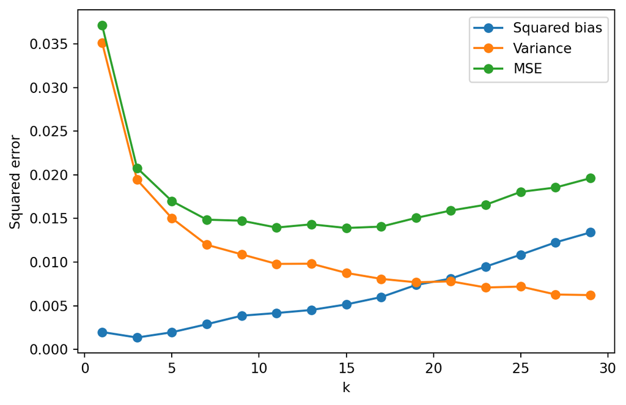

```python
plt.figure(figsize=(7, 4.5))
plt.plot(q1_k, q1_bias**2, "o-", label="Squared bias")
plt.plot(q1_k, q1_var, "o-", label="Variance")
plt.plot(q1_k, q1_mse, "o-", label="MSE")
plt.xlabel("k")
plt.ylabel("Squared error")
plt.legend()
plt.show()
```

**Pattern.** Variance drops sharply as $k$ grows (about 0.035 at $k=1$ down to about 0.006 at $k=29$) because the prediction averages more responses, and because the set of neighbors is less sensitive to exactly where the random training points happen to fall. Squared bias moves the other way (about 0.002 up to about 0.013): larger neighborhoods reach points farther from $\mathbf x_0$ whose mean responses differ from $f(\mathbf x_0)$. Because $\mathbf x_0$ is away from the center of the standard normal cloud, most extra neighbors come from the side closer to the origin, so the bias is systematic rather than canceling out (it is negative here). MSE is U shaped: high at $k=1$ (variance dominated), lowest around $k\approx 11$ to $15$, then rising again as bias takes over. The small wiggles are Monte Carlo noise from only 200 repetitions. Note the variance is much larger than $0.1^2/k$, since the neighbor locations change across repetitions too, not just the response noise.

**Comparison with ridge/lasso.** $k$ plays the same role as the penalty $\lambda$. Small $k$ is like small $\lambda$: a flexible, low bias, high variance fit. Large $k$ is like large $\lambda$: a smoother, more constrained fit with lower variance but more bias, and the best MSE sits at an intermediate value in both cases. The mechanism differs: ridge and lasso shrink coefficients of a global linear model toward zero, while KNN smooths by averaging more local responses and makes no global shape assumption. So KNN’s bias comes from averaging over a wider region, while penalized regression’s bias comes from shrinkage plus any misspecification already built into the linear form.

## Question 2: Compare KNN with lasso

Use the response model from Question 1, including the noise standard deviation $0.1$, but generate $p=30$ covariates. The response still depends only on the first three. Consider these two settings:

- **Setting 1:** all 30 covariates are independent standard normal variables.
- **Setting 2:** the covariates have a multivariate normal distribution with mean zero and covariance matrix $\boldsymbol\Sigma$, where

  $$\Sigma_{jj}=1,
  \qquad
  \Sigma_{jl}=0.8\quad\text{for }j\ne l.$$

In each setting, generate 400 training observations and 1,000 independent test observations. Fit 5NN using Euclidean distance on the supplied covariate scale. All covariates already have population variance one.

For lasso, use a linear model containing the 30 covariates and a separately fitted, unpenalized intercept. Follow the Week 4 objective,

$$L_\lambda(\boldsymbol\beta)
=\frac{1}{2n}\left\lVert
\widetilde{\mathbf y}-\mathbf X\boldsymbol\beta
\right\rVert_2^2
+\lambda\lVert\boldsymbol\beta\rVert_1,$$

where $\mathbf X\in\mathbb R^{n\times30}$ contains the centered and standardized covariates and $\widetilde{\mathbf y}$ is the centered training response. Select the penalty by ten-fold cross-validation over 41 logarithmically spaced values from $10^{-4}$ to $1$. Estimate all means and scales using only the training portion of each fold, with divisor equal to that portion’s sample size. After selecting the penalty, refit on all training observations and apply the fitted transformations unchanged to the test observations. Do not add nonlinear terms to the lasso model.

1. Fit both methods in each setting. Use the same training and test data for the two methods within a setting. Report their test MSE values in one table, together with the selected lasso penalty and the number of nonzero lasso slopes. You only need to generate one dataset for each setting; repeated simulations are not required.

**Answer 2a.** Seed `4322` (NumPy `default_rng`). For each setting I draw 1,400 observations, use the first 400 for training and the last 1,000 for testing, and give both methods the same split. Setting 2 uses $\boldsymbol\Sigma = 0.2\mathbf I + 0.8\mathbf 1\mathbf 1^{\mathsf T}$ through its Cholesky factor.

5NN uses equal weights and Euclidean distance on the raw covariates (all have population variance one). For lasso, each CV fold computes column means, column SDs (divisor = fold training size) and the response mean from the fold’s training part only, fits scikit-learn’s `Lasso` without an intercept on the standardized $\mathbf X$ and centered $\widetilde{\mathbf y}$, then adds the response mean back. scikit-learn’s `alpha` uses exactly the $\frac{1}{2n}\lVert\cdot\rVert_2^2+\lambda\lVert\boldsymbol\beta\rVert_1$ objective, so `alpha` $=\lambda$. The chosen $\lambda$ minimizes average validation MSE over 41 values from $10^{-4}$ to $1$, and the final fit reuses all 400 training rows with the full training means and SDs applied unchanged to the test set.

**Show the workflow**

```python
from sklearn.neighbors import KNeighborsRegressor
from sklearn.linear_model import Lasso

q2_rng = np.random.default_rng(4322)
n, p, n_test = 400, 30, 1000
lambda_grid = np.logspace(-4, 0, 41)

def fit_lasso(X_tr, y_tr, lam):
    """Standardize with training-only stats (divisor n), center y, fit lasso."""
    mu = X_tr.mean(axis=0)
    sd = X_tr.std(axis=0, ddof=0)
    y_mean = y_tr.mean()
    model = Lasso(alpha=lam, fit_intercept=False, tol=1e-8, max_iter=100000)
    model.fit((X_tr - mu) / sd, y_tr - y_mean)
    predict = lambda X_new: model.predict((X_new - mu) / sd) + y_mean
    return predict, model.coef_

rows, q2_coefs = [], {}
for name, rho in [("Setting 1 (independent)", 0.0),
                  ("Setting 2 (correlation 0.8)", 0.8)]:
    Sigma = (1 - rho) * np.eye(p) + rho
    L = np.linalg.cholesky(Sigma)
    X_all = q2_rng.standard_normal((n + n_test, p)) @ L.T
    y_all = f_true(X_all) + q2_rng.normal(0, 0.1, n + n_test)
    X_tr, y_tr = X_all[:n], y_all[:n]
    X_te, y_te = X_all[n:], y_all[n:]

    # 5NN on the supplied scale
    knn = KNeighborsRegressor(n_neighbors=5, weights="uniform", algorithm="brute")
    knn.fit(X_tr, y_tr)
    knn_mse = np.mean((y_te - knn.predict(X_te))**2)

    # 10-fold CV for lambda, all transformations estimated within the fold
    folds = q2_rng.permutation(np.repeat(np.arange(10), n // 10))
    cv_err = np.zeros((10, len(lambda_grid)))
    for j in range(10):
        tr = folds != j
        for h, lam in enumerate(lambda_grid):
            pred_fn, _ = fit_lasso(X_tr[tr], y_tr[tr], lam)
            cv_err[j, h] = np.mean((y_tr[~tr] - pred_fn(X_tr[~tr]))**2)
    lam_best = lambda_grid[np.argmin(cv_err.mean(axis=0))]

    # Refit on all training data
    pred_fn, coef = fit_lasso(X_tr, y_tr, lam_best)
    lasso_mse = np.mean((y_te - pred_fn(X_te))**2)
    q2_coefs[name] = coef
    rows.append({"Setting": name, "5NN test MSE": knn_mse,
                 "Lasso test MSE": lasso_mse, "Selected lambda": lam_best,
                 "Nonzero lasso slopes": int(np.sum(coef != 0))})

q2_results = pd.DataFrame(rows)
q2_results.round(4)
```

|  | Setting | 5NN test MSE | Lasso test MSE | Selected lambda | Nonzero lasso slopes |
| --- | --- | --- | --- | --- | --- |
| 0 | Setting 1 (independent) | 0.5652 | 0.2437 | 0.0251 | 11 |
| 1 | Setting 2 (correlation 0.8) | 0.1777 | 0.2621 | 0.0158 | 11 |

For reference, the refit lasso slopes (on the standardized scale) for $X_1$ through $X_5$:

**Show the workflow**

```python
pd.DataFrame({k: v[:5] for k, v in q2_coefs.items()},
             index=[f"X{j}" for j in range(1, 6)]).round(3)
```

|  | Setting 1 (independent) | Setting 2 (correlation 0.8) |
| --- | --- | --- |
| X1 | 0.452 | 0.462 |
| X2 | 0.607 | 0.504 |
| X3 | 0.044 | -0.000 |
| X4 | 0.000 | -0.067 |
| X5 | 0.000 | -0.000 |

2. Compare the results between the two settings. Explain how correlation can change the usefulness of Euclidean neighborhoods, and why lasso does not use all covariates in the same way as KNN.

**Answer 2b.** The ranking flips between settings. With independent covariates lasso wins clearly (test MSE about 0.24 vs 0.57 for 5NN). With correlated covariates 5NN improves a lot (about 0.18) and beats lasso (about 0.26), while lasso’s error barely moves.

*Why correlation helps the neighborhoods.* In Setting 1 each of the 27 irrelevant covariates adds its own independent squared difference to the Euclidean distance. The distance is dominated by noise coordinates, so the “nearest” five points in $\mathbb R^{30}$ are often not close in $(X_1,X_2,X_3)$, which is the curse of dimensionality in action. In Setting 2 all coordinates share a strong common factor, so the data effectively concentrate near a lower dimensional structure: about 80% of each covariate’s variance is a shared component. Two points that are close in all 30 coordinates are then very likely close in the three that matter, and the irrelevant coordinates contribute much less independent noise to the distance. The neighborhoods become more informative about $f$.

*Why lasso behaves differently.* KNN treats every coordinate equally in the distance; it has no way to learn that $X_4,\ldots,X_{30}$ are irrelevant. Lasso estimates a separate slope for each covariate and can set most of them to zero, so it largely ignores irrelevant covariates in both settings (11 nonzero slopes here, with the large ones on $X_1$ and $X_2$). That is why its performance is fairly stable across settings. Under correlation, lasso has a different problem: correlated covariates can substitute for each other, so small slopes on irrelevant covariates can act as proxies for the relevant ones, and selection becomes less stable. It does not gain the neighborhood benefit that KNN does.

3. The response model contains $\sin(X_2)$ and $X_3^2$, but the lasso fit uses only linear terms. Explain how this difference affects the comparison. Would the results justify a general claim that correlation always helps KNN, or that one method is always better? Explain why.

**Answer 2c.** The lasso model is misspecified. It can capture the linear $0.5X_1$ part and the roughly linear central part of $\sin(X_2)$, but it cannot represent the curvature of $\sin(X_2)$ in the tails or the $-0.3X_3^2$ term at all (the fitted slope on $X_3$ is near zero because $X_3^2$ is symmetric in $X_3$). The intercept absorbs the average of $-0.3X_3^2$, but the variation around that average ends up in the error. So lasso’s test MSE has a floor well above the noise variance $0.01$ no matter how well it selects variables. KNN has no such floor in principle, since it is nonparametric, but its error depends on how good the neighborhoods are. The comparison therefore mixes two effects: KNN’s sensitivity to dimension and geometry, and lasso’s approximation error from forcing a linear form. If the truth were linear, lasso would likely win in both settings; with nonlinear terms added to the lasso design, the gap would also change.

These results do not justify either general claim. They come from one dataset per setting, one correlation structure (equicorrelation 0.8, where every irrelevant covariate is tied to the relevant ones), one $f$, one $n$, and $k=5$ fixed. Correlation helped KNN here because the irrelevant coordinates became largely redundant with the relevant ones; a correlation structure among only the irrelevant covariates, or one where the relevant signal lives in a direction the shared factor washes out, need not help and could hurt. Likewise, which method is better depends on the true regression function, the dimension, the sample size, and the tuning. A general claim would need repeated simulations over many designs, and even then it would only hold for the conditions studied.

## Question 3: Observed dimension and latent dimension

The lecture’s handwritten digit example shows that KNN can work with many measured covariates. We will use a simulation to investigate why the structure of those covariates matters.

Let $p=100$ be the number of observed covariates and let $m$ be the number of latent variables. For each observation, generate

$$\mathbf X_i=\mathbf A\mathbf Z_i+\boldsymbol\eta_i,
\qquad
Y_i=Z_{i1}+Z_{i2}+\epsilon_i,$$

where $\mathbf A\in\mathbb R^{100\times m}$ has independent entries from Uniform$[-2,2]$. The entries of $\mathbf Z_i\in\mathbb R^m$ and $\boldsymbol\eta_i\in\mathbb R^{100}$, and the scalar $\epsilon_i$, are independent standard normal variables, also independent of $\mathbf A$. Generate $\mathbf A$ once and use it for all training and test observations in that dataset.

Compare $m=3$ and $m=30$. In each setting, generate 200 training observations and 200 independent test observations. Fit KNN using only the 100 observed covariates in $\mathbf X$, with Euclidean distance on their generated scale. The latent variables in $\mathbf Z$ are used to generate the data but are not available to the fitted model. Consider $k=2,10,18,\ldots,82$.

1. Generate one dataset for each value of $m$. Fit KNN for every value of $k$ and calculate test MSE. Within a setting, use the same training and test observations for all values of $k$.

**Answer 3a.** Seed `4323` (NumPy `default_rng`). For each $m$, I draw $\mathbf A$ once, then 400 observations of $(\mathbf Z_i,\boldsymbol\eta_i,\epsilon_i)$; rows 1 to 200 are training and 201 to 400 are test, all sharing that $\mathbf A$. KNN sees only $\mathbf X$. Since every $k$ uses the same data, I compute the $200\times200$ test-to-training Euclidean distance matrix once, sort each row, and average the first $k$ training responses (equal weights).

**Show the workflow**

```python
q3_rng = np.random.default_rng(4323)
q3_p = 100
m_values = [3, 30]
q3_k = np.arange(2, 83, 8)

def latent_experiment(rng, m, n_tr=200, n_te=200):
    A = rng.uniform(-2, 2, size=(q3_p, m))          # fixed for this dataset
    Z = rng.standard_normal((n_tr + n_te, m))
    X = Z @ A.T + rng.standard_normal((n_tr + n_te, q3_p))
    y = Z[:, 0] + Z[:, 1] + rng.standard_normal(n_tr + n_te)
    X_tr, y_tr, X_te, y_te = X[:n_tr], y[:n_tr], X[n_tr:], y[n_tr:]
    d2 = np.sum((X_te[:, None, :] - X_tr[None, :, :])**2, axis=2)
    order = np.argsort(d2, axis=1, kind="stable")
    return np.array([np.mean((y_te - y_tr[order[:, :k]].mean(axis=1))**2)
                     for k in q3_k])

q3_one = {f"m = {m}": latent_experiment(q3_rng, m) for m in m_values}
pd.DataFrame({"k": q3_k, **q3_one}).round(4)
```

|  | k | m = 3 | m = 30 |
| --- | --- | --- | --- |
| 0 | 2 | 1.8872 | 3.0776 |
| 1 | 10 | 1.4462 | 2.4446 |
| 2 | 18 | 1.4047 | 2.4016 |
| 3 | 26 | 1.4570 | 2.4012 |
| 4 | 34 | 1.4851 | 2.3938 |
| 5 | 42 | 1.5425 | 2.4645 |
| 6 | 50 | 1.5907 | 2.4491 |
| 7 | 58 | 1.6370 | 2.4997 |
| 8 | 66 | 1.7032 | 2.5386 |
| 9 | 74 | 1.7801 | 2.5767 |
| 10 | 82 | 1.8631 | 2.6171 |

In this single dataset $m=3$ gives a much lower test MSE than $m=30$ at every $k$. For reference, $\operatorname{Var}(Y)=3$, so a predictor that always outputs 0 would have MSE near 3, and the best possible MSE is 1 (the variance of $\epsilon$).

2. Repeat the complete experiment 50 times, generating a new $\mathbf A$ and new observations in each repetition. Plot average test MSE against $k$, with one curve for each value of $m$. These curves compare the specified choices of $k$ in a controlled simulation; they are not a cross-validation procedure for selecting a final model.

**Answer 3b.** Continuing with the same generator, each of the 50 repetitions draws a new $\mathbf A$ and new data for each $m$.

**Show the workflow**

```python
nrep = 50
q3_mse = np.zeros((nrep, len(q3_k), len(m_values)))
for r in range(nrep):
    for s, m in enumerate(m_values):
        q3_mse[r, :, s] = latent_experiment(q3_rng, m)
q3_avg = q3_mse.mean(axis=0)
pd.DataFrame({"k": q3_k, "m = 3": q3_avg[:, 0], "m = 30": q3_avg[:, 1]}).round(4)
```

|  | k | m = 3 | m = 30 |
| --- | --- | --- | --- |
| 0 | 2 | 1.6697 | 3.0553 |
| 1 | 10 | 1.2926 | 2.3426 |
| 2 | 18 | 1.3108 | 2.3443 |
| 3 | 26 | 1.3553 | 2.3748 |
| 4 | 34 | 1.4046 | 2.4128 |
| 5 | 42 | 1.4594 | 2.4482 |
| 6 | 50 | 1.5150 | 2.4840 |
| 7 | 58 | 1.5721 | 2.5145 |
| 8 | 66 | 1.6305 | 2.5459 |
| 9 | 74 | 1.6892 | 2.5737 |
| 10 | 82 | 1.7504 | 2.6043 |

**Show the workflow**

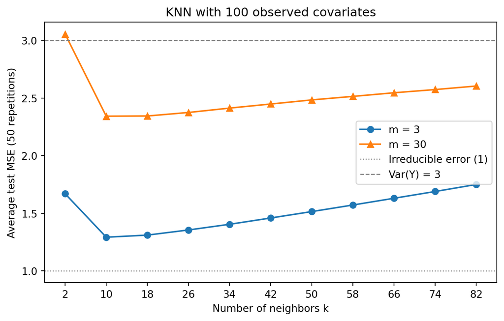

```python
plt.figure(figsize=(7, 4.5))
plt.plot(q3_k, q3_avg[:, 0], "o-", label="m = 3")
plt.plot(q3_k, q3_avg[:, 1], "^-", label="m = 30")
plt.axhline(1, color="gray", ls=":", lw=1, label="Irreducible error (1)")
plt.axhline(3, color="gray", ls="--", lw=1, label="Var(Y) = 3")
plt.xlabel("Number of neighbors k")
plt.ylabel("Average test MSE (50 repetitions)")
plt.title("KNN with 100 observed covariates")
plt.xticks(q3_k)
plt.legend()
plt.tight_layout()
plt.show()
```

The $m=3$ curve sits well below the $m=30$ curve for every $k$ (roughly 1.3 vs 2.3 at the best $k$). Both are U shaped, with the minimum around $k=10$ to $18$: $k=2$ averages too few noisy responses, while large $k$ averages over neighbors that are no longer close in $(Z_1,Z_2)$. For $m=30$ even the best $k$ only explains a modest share of $\operatorname{Var}(Y)=3$, and at $k=2$ it is slightly worse than just predicting 0. As the question says, these are averages from a controlled simulation, not a CV procedure for picking $k$.

3. Both settings have 100 observed covariates, and the response depends on only two latent variables. Explain why their KNN performance can still differ. What role does the noise $\boldsymbol\eta_i$ play, and why are the observed data not confined exactly to an $m$-dimensional linear space?

**Answer 3c.** What matters for KNN is the intrinsic dimension of the data, not the number of columns. Write $\lVert\mathbf X_i-\mathbf X_j\rVert^2 = \lVert\mathbf A(\mathbf Z_i-\mathbf Z_j)+(\boldsymbol\eta_i-\boldsymbol\eta_j)\rVert^2$. When $m=3$, the signal part of the distance is driven by only 3 latent coordinates, two of which are exactly the ones the response uses. Points that are close in $\mathbf X$ tend to be close in $\mathbf Z$, and therefore in $Z_1+Z_2$, so neighbors carry useful information about $Y$. With 200 training points, 3 dimensions are also sampled densely enough that real near neighbors exist.

When $m=30$, the distance mixes 30 latent directions and only 2 of them affect $Y$. The other 28 act like irrelevant covariates: two points can be close in $(Z_1,Z_2)$ but far apart in the other 28, and the nearest neighbors in $\mathbf X$ are chosen mostly by those irrelevant directions. In 30 dimensions, 200 points are also far too sparse for true local neighborhoods. So the curse of dimensionality applies to $m$, even though $p=100$ in both settings.

*Role of $\boldsymbol\eta_i$.* The noise adds an independent $\mathcal N(0,1)$ perturbation to each of the 100 coordinates. It contributes about $2\times100=200$ to the expected squared distance between any two points regardless of how similar their latent variables are, which blurs the ranking of neighbors and can change which training points are nearest. Its impact is relative to the signal: with $m=3$ the signal part $\mathbf A(\mathbf Z_i-\mathbf Z_j)$ has large variance along a few directions (each column of $\mathbf A$ has squared norm about $100\times4/3\approx133$), so latent differences still dominate the ranking. With $m=30$ the signal is spread across many directions, and the relevant two are a small part of it.

*Why the data are not exactly $m$-dimensional.* Without noise, $\mathbf X_i=\mathbf A\mathbf Z_i$ would lie exactly in the column space of $\mathbf A$, a linear subspace of dimension at most $m$. Adding $\boldsymbol\eta_i$, which is full rank noise in all 100 coordinates and independent of $\mathbf Z_i$, pushes each point off that subspace in every direction. The observed data have full 100-dimensional support: they concentrate near an $m$-dimensional subspace (a thick “slab”) rather than lying on it. That is why the setting is “low-dimensional signal plus noise” and KNN performance depends on both the latent dimension and the signal-to-noise ratio, not just on $m$.

## Question 4: Classify handwritten digits

Use `zip.train` and `zip.test` from the R package `ElemStatLearn`, as in the lecture. The package has been retired from the active CRAN repository. If needed, install the [archived package](https://cran.r-project.org/src/contrib/Archive/ElemStatLearn/ElemStatLearn_2015.6.26.2.tar.gz) into your usual R library, then load the two datasets. Python users can use the course copies of the same [training data](https://teazrq.github.io/stat432rpy/data/knn/zip-train.csv.gz) and [test data](https://teazrq.github.io/stat432rpy/data/knn/zip-test.csv.gz). These compressed CSV files have no headers and are included in the homework ZIP under `data/knn`. Run the Python code from the folder containing `data`.

Each image has $16\times16=256$ pixel values. The first column is the digit label and the remaining columns are the pixel values. Use the first 1,000 rows of `zip.train` and the first 500 rows of `zip.test`. Use the original pixel values without standardization, and do not include the digit label in a distance calculation.

For a test image $\mathbf x_0$ and a training image $\mathbf x_i$, the two distances are

$$d_E(\mathbf x_0,\mathbf x_i)
=\sqrt{\sum_{j=1}^{256}(x_{0j}-x_{ij})^2},
\qquad
d_M(\mathbf x_0,\mathbf x_i)
=\sum_{j=1}^{256}|x_{0j}-x_{ij}|.$$

1. Write a 5NN classification function that allows either Euclidean or Manhattan distance. For each test image, calculate its distances to the training images directly, find the five nearest, and return the most frequent digit label. Break distance ties by the smaller training row number and voting ties by the smallest digit. Do not use a built-in distance or KNN function for this part.

**Answer 4a.** I read the course CSV copies from `data/knn/`, keep the first 1,000 training rows and the first 500 test rows, and split off column 1 as the label. The distances are computed directly with array arithmetic. `np.argsort(..., kind="stable")` keeps equal distances in training row order, so the smaller row number wins a distance tie. `np.bincount(..., minlength=10)` counts votes for digits 0 to 9 and `np.argmax` returns the first maximum, so a voting tie goes to the smallest digit. No built-in distance or KNN routine is used.

**Show the workflow**

```python
zip_train = np.loadtxt("data/knn/zip-train.csv.gz", delimiter=",")
zip_test = np.loadtxt("data/knn/zip-test.csv.gz", delimiter=",")

X_zip = zip_train[:1000, 1:]
y_zip = zip_train[:1000, 0].astype(int)
X_zip_test = zip_test[:500, 1:]
y_zip_test = zip_test[:500, 0].astype(int)

def euclidean(x0, X):
    return np.sqrt(np.sum((X - x0)**2, axis=1))

def manhattan(x0, X):
    return np.sum(np.abs(X - x0), axis=1)

def knn5_classify(X_train, y_train, X_new, distance="euclidean", k=5):
    dist_fn = {"euclidean": euclidean, "manhattan": manhattan}[distance]
    y_hat = np.empty(X_new.shape[0], dtype=int)
    for i, x0 in enumerate(X_new):
        d = dist_fn(x0, X_train)
        nearest = np.argsort(d, kind="stable")[:k]        # ties -> smaller row
        votes = np.bincount(y_train[nearest], minlength=10)
        y_hat[i] = np.argmax(votes)                       # ties -> smaller digit
    return y_hat

print("Training:", X_zip.shape, " Test:", X_zip_test.shape)
```

```
Training: (1000, 256)  Test: (500, 256)
```

2. Apply the classifier to all 500 test images using each distance. For each fit, report the test classification error and a $10\times10$ confusion matrix, with rows representing predicted digits and columns representing true digits. Keep all digit labels from 0 through 9 in the matrix, including any with a zero count. Which digits are most often confused with one another?

**Answer 4b.**

**Show the workflow**

```python
pred_E = knn5_classify(X_zip, y_zip, X_zip_test, "euclidean")
pred_M = knn5_classify(X_zip, y_zip, X_zip_test, "manhattan")

def confusion(pred, truth):
    C = np.zeros((10, 10), dtype=int)
    for a, b in zip(pred, truth):
        C[a, b] += 1
    return pd.DataFrame(C, index=pd.Index(range(10), name="Predicted"),
                        columns=pd.Index(range(10), name="True"))

pd.DataFrame({"Distance": ["Euclidean", "Manhattan"],
              "Errors (of 500)": [np.sum(pred_E != y_zip_test),
                                  np.sum(pred_M != y_zip_test)],
              "Test error": [np.mean(pred_E != y_zip_test),
                             np.mean(pred_M != y_zip_test)]})
```

|  | Distance | Errors (of 500) | Test error |
| --- | --- | --- | --- |
| 0 | Euclidean | 61 | 0.122 |
| 1 | Manhattan | 69 | 0.138 |

Euclidean confusion matrix (rows = predicted, columns = true):

**Show the workflow**

```python
conf_E = confusion(pred_E, y_zip_test)
conf_E
```

| True Predicted | 0 | 1 | 2 | 3 | 4 | 5 | 6 | 7 | 8 | 9 |
| --- | --- | --- | --- | --- | --- | --- | --- | --- | --- | --- |
| 0 | 118 | 0 | 7 | 1 | 0 | 4 | 2 | 0 | 2 | 0 |
| 1 | 0 | 66 | 0 | 0 | 2 | 0 | 0 | 0 | 0 | 1 |
| 2 | 0 | 0 | 39 | 1 | 0 | 0 | 2 | 0 | 0 | 1 |
| 3 | 0 | 0 | 0 | 23 | 0 | 4 | 0 | 0 | 2 | 0 |
| 4 | 0 | 0 | 1 | 0 | 27 | 1 | 1 | 1 | 0 | 1 |
| 5 | 0 | 0 | 0 | 1 | 0 | 13 | 0 | 0 | 0 | 0 |
| 6 | 0 | 2 | 0 | 0 | 0 | 1 | 41 | 0 | 2 | 0 |
| 7 | 0 | 0 | 0 | 0 | 1 | 1 | 0 | 34 | 0 | 4 |
| 8 | 0 | 0 | 3 | 2 | 0 | 2 | 0 | 0 | 37 | 0 |
| 9 | 1 | 0 | 0 | 1 | 4 | 0 | 0 | 1 | 1 | 41 |

Manhattan confusion matrix (rows = predicted, columns = true):

**Show the workflow**

```python
conf_M = confusion(pred_M, y_zip_test)
conf_M
```

| True Predicted | 0 | 1 | 2 | 3 | 4 | 5 | 6 | 7 | 8 | 9 |
| --- | --- | --- | --- | --- | --- | --- | --- | --- | --- | --- |
| 0 | 118 | 0 | 6 | 1 | 0 | 5 | 3 | 0 | 4 | 0 |
| 1 | 0 | 67 | 2 | 0 | 2 | 0 | 1 | 0 | 0 | 1 |
| 2 | 0 | 0 | 35 | 0 | 0 | 0 | 2 | 0 | 0 | 0 |
| 3 | 0 | 0 | 1 | 24 | 0 | 4 | 0 | 0 | 2 | 0 |
| 4 | 0 | 0 | 1 | 1 | 27 | 1 | 0 | 1 | 0 | 1 |
| 5 | 0 | 0 | 0 | 1 | 0 | 11 | 0 | 0 | 0 | 0 |
| 6 | 0 | 1 | 0 | 0 | 0 | 2 | 40 | 0 | 2 | 0 |
| 7 | 0 | 0 | 2 | 1 | 1 | 0 | 0 | 34 | 0 | 5 |
| 8 | 0 | 0 | 2 | 0 | 0 | 3 | 0 | 0 | 34 | 0 |
| 9 | 1 | 0 | 1 | 1 | 4 | 0 | 0 | 1 | 2 | 41 |

Largest off-diagonal cells, listed as true digit → predicted digit:

**Show the workflow**

```python
def top_confusions(C, n_top=6):
    out = [(C.iloc[i, j], f"{j} -> {i}") for i in range(10) for j in range(10)
           if i != j and C.iloc[i, j] > 0]
    out.sort(key=lambda t: -t[0])
    return [f"{lab} ({cnt})" for cnt, lab in out[:n_top]]

pd.DataFrame({"Euclidean": top_confusions(conf_E),
              "Manhattan": top_confusions(conf_M)})
```

|  | Euclidean | Manhattan |
| --- | --- | --- |
| 0 | 2 -> 0 (7) | 2 -> 0 (6) |
| 1 | 5 -> 0 (4) | 5 -> 0 (5) |
| 2 | 5 -> 3 (4) | 9 -> 7 (5) |
| 3 | 9 -> 7 (4) | 8 -> 0 (4) |
| 4 | 4 -> 9 (4) | 5 -> 3 (4) |
| 5 | 2 -> 8 (3) | 4 -> 9 (4) |

Euclidean 5NN makes 61 errors (test error 0.122) and Manhattan 5NN makes 69 (0.138). Every digit label 0 to 9 appears in both matrices. The most common single mistake under both distances is a true **2 predicted as 0** (7 times with Euclidean, 6 with Manhattan); many 0s in the training data act as “catch all” neighbors for round, heavy strokes. Other frequent confusions are **4 ↔︎ 9** and **7 ↔︎ 9** (similar upper strokes and vertical stems), **5 → 3** and **5 → 0** (5 is the smallest class in this test set, 26 images, yet is misclassified often), and a few **2/3/5 → 8** cases. Counting both directions, the pairs confused most often are 0/2, 3/5, 4/9, and 7/9. Class sizes differ (119 zeros but only 26 fives among these 500), so raw counts favor large classes.

3. For Euclidean distance, display three incorrectly classified test images, together with their true and predicted labels. Comment on whether the mistakes are visually understandable. Compare the overall results of the two distance measures. Can they have similar total error while making mistakes on different images? Use your predictions to support your answer.

**Answer 4c.** The first three Euclidean errors in test row order (pixel values run from $-1$ to $1$, shown dark for high values):

**Show the workflow**

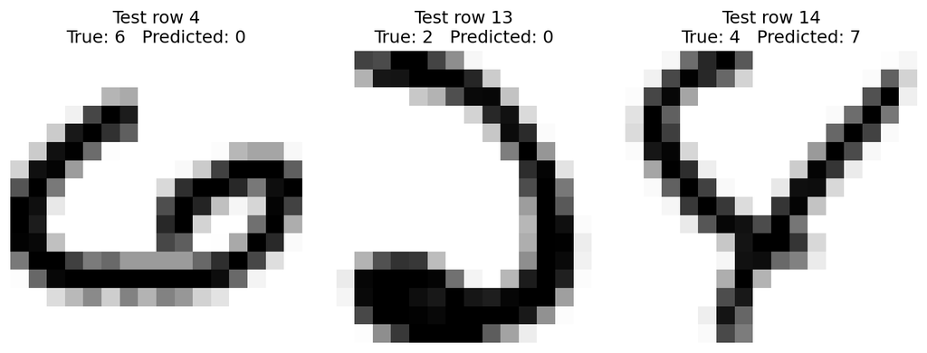

```python
wrong_E = np.flatnonzero(pred_E != y_zip_test)[:3]
fig, axes = plt.subplots(1, 3, figsize=(9, 3.4))
for ax, i in zip(axes, wrong_E):
    ax.imshow(X_zip_test[i].reshape(16, 16), cmap="gray_r", vmin=-1, vmax=1,
              interpolation="nearest")
    ax.set_title(f"Test row {i + 1}\nTrue: {y_zip_test[i]}   Predicted: {pred_E[i]}")
    ax.axis("off")
plt.tight_layout()
plt.show()
```

These are test rows 4, 13, and 14. The **6 predicted as 0** is written wide and flat: the lower loop fills most of the frame and the upper stroke is short, so most of its dark pixels sit where a round 0 would put them. The **2 predicted as 0** has no diagonal stroke; it is a top bar, a curved right side, and a thick base, which traces most of a 0’s outline and is only open on the left. The **4 predicted as 7** is written like a Y, with two arms meeting over a short stem and no horizontal crossbar; the long diagonal from the upper right down to the stem looks like the main stroke of a 7. All three are understandable: a person can still read them using stroke order and small features, but KNN compares raw pixel overlap, and a few differing pixels in a key spot count the same as any other pixels.

**Show the workflow**

```python
agree = pd.crosstab(pd.Series(np.where(pred_E == y_zip_test, "correct", "wrong"),
                              name="Euclidean"),
                    pd.Series(np.where(pred_M == y_zip_test, "correct", "wrong"),
                              name="Manhattan"))
both_wrong_diff = np.sum((pred_E != y_zip_test) & (pred_M != y_zip_test)
                         & (pred_E != pred_M))
print("Test images where the two predictions differ:", np.sum(pred_E != pred_M))
print("Both wrong but predicting different digits:", both_wrong_diff)
agree
```

```
Test images where the two predictions differ: 22
Both wrong but predicting different digits: 8
```

| Manhattan Euclidean | correct | wrong |
| --- | --- | --- |
| correct | 428 | 11 |
| wrong | 3 | 58 |

Overall, Euclidean is slightly better (61 vs 69 errors), but the totals hide substantial disagreement. The two distances predict different labels on 22 of 500 images. Euclidean is right and Manhattan wrong on 11 images, Manhattan is right and Euclidean wrong on 3, and on 8 more both are wrong but guess different digits. Only 50 images get the identical wrong label from both. So yes, two methods with similar total error can make different mistakes: 11 of Euclidean’s 61 errors and 19 of Manhattan’s 69 are not the same mistake under the other distance. The difference comes from how the distances weight pixel disagreements. Squaring makes Euclidean penalize a few large pixel differences heavily, while Manhattan adds up all differences linearly, so it is relatively more affected by many small, diffuse differences such as slight stroke thickness or shift. That changes which 5 training images are nearest for borderline test digits. This is one split with 1,000 training images, so it does not show that Euclidean is better in general.

## Question 5: Create a plot-formatting skill

Create a short `SKILL.md` file for improving the formatting of STAT 432 homework plots. You may use AI to help write it.

1. Include a title, a description, and a few formatting rules. The description should limit the skill to STAT 432 homework plot improvements and require an explicit request to use it. Your rules should address margins, titles, axes, labels, colors, and sizes for plots produced in R or Python. Keep them portable: do not refer to specific homework questions.

**Answer 5a.** I wrote `format-homework-plots/SKILL.md` (saved next to this file; the full final text is appended in 5c). It has:

- **Title and description:** the YAML front matter names the skill `format-homework-plots`, and the description limits it to formatting STAT 432 homework plots and says to use it only when the user explicitly asks for it by name. It also rules out changing data, analysis, or results.
- **Rules** grouped by the required topics: size and margins (default 7 × 4.5 in, no clipping via `tight_layout` or `par(mar)`), titles and labels (descriptive title, axis labels in words with symbols, fixed font sizes), axes (ticks at the tuning grid, y starting at 0 for error quantities, log scale only when justified, light grid), and colors and legends (Okabe-Ito colorblind palette, redundant marker/line styles, emphasis on the main summary, legend placement).

The rules only mention generic plot types (tuning grids, error curves), so they carry over to any homework and to either R or Python.

2. Ask your agent to install the skill. Explicitly call it to improve the plot from Question 1, then compare the original and revised versions. Do you like the changes? You may revise the skill and test it a couple more times, or uninstall it if it remains unhelpful.

**Answer 5b.** I saved the skill as `format-homework-plots/SKILL.md`, installed it for my agent, and then called it explicitly: *“Use `format-homework-plots` to improve the formatting of my Question 1 plot.”* The data are the same `q1_k`, `q1_bias`, `q1_var`, and `q1_mse` arrays from Question 1; only the plotting code changed.

**Original (from 1b):**

**Show the workflow**

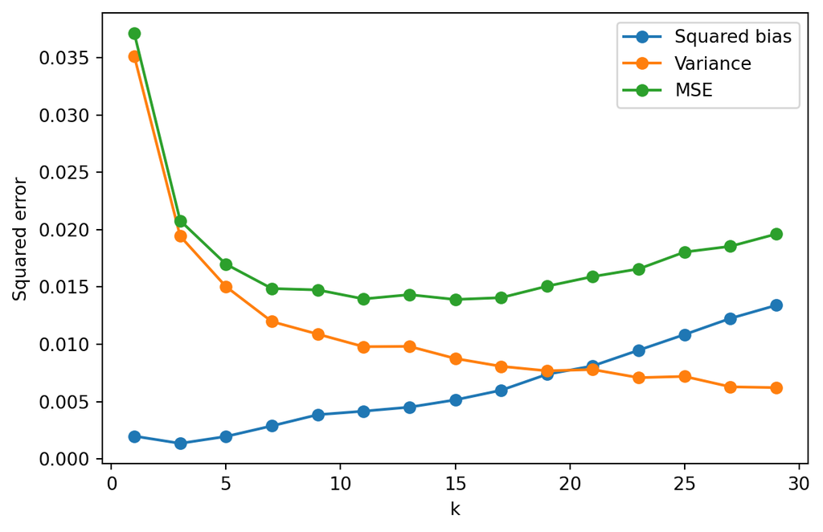

```python
plt.figure(figsize=(7, 4.5))
plt.plot(q1_k, q1_bias**2, "o-", label="Squared bias")
plt.plot(q1_k, q1_var, "o-", label="Variance")
plt.plot(q1_k, q1_mse, "o-", label="MSE")
plt.xlabel("k")
plt.ylabel("Squared error")
plt.legend()
plt.show()
```

**Revised with the skill:**

**Show the workflow**

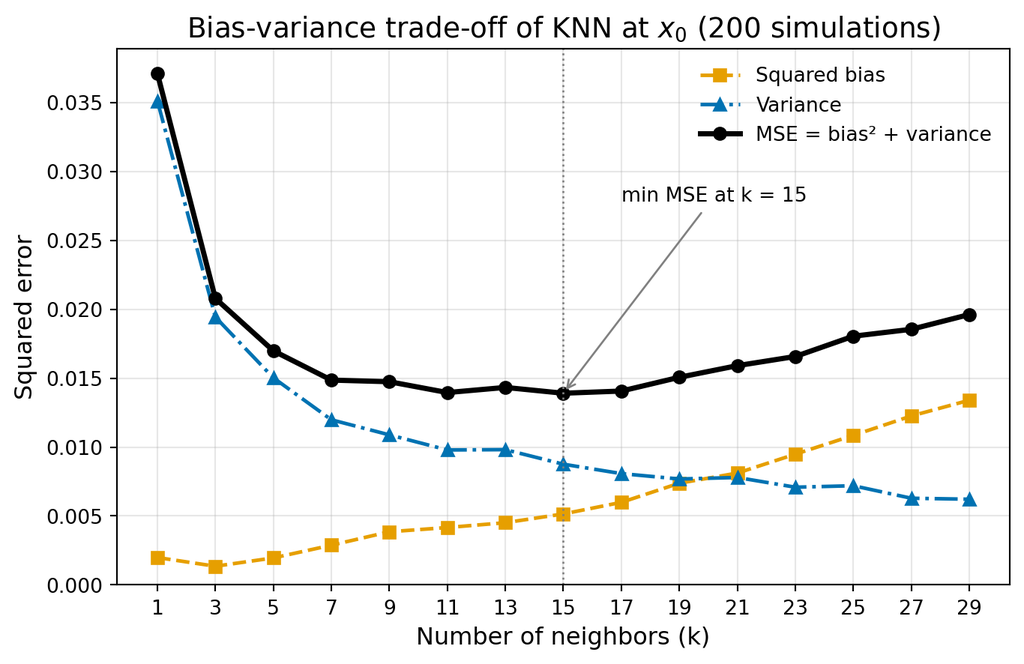

```python
okabe_ito = {"orange": "#E69F00", "blue": "#0072B2", "black": "#000000"}
fig, ax = plt.subplots(figsize=(7, 4.5), layout="constrained")
ax.plot(q1_k, q1_bias**2, marker="s", ls="--", color=okabe_ito["orange"],
        lw=1.8, label="Squared bias")
ax.plot(q1_k, q1_var, marker="^", ls="-.", color=okabe_ito["blue"],
        lw=1.8, label="Variance")
ax.plot(q1_k, q1_mse, marker="o", ls="-", color=okabe_ito["black"],
        lw=2.6, label="MSE = bias² + variance")
k_best = q1_k[np.argmin(q1_mse)]
ax.axvline(k_best, color="gray", ls=":", lw=1)
ax.annotate(f"min MSE at k = {k_best}", xy=(k_best, q1_mse.min()),
            xytext=(k_best + 2, q1_mse.max() * 0.75), fontsize=10,
            arrowprops=dict(arrowstyle="->", color="gray"))
ax.set_title("Bias-variance trade-off of KNN at $x_0$ (200 simulations)",
             fontsize=14)
ax.set_xlabel("Number of neighbors (k)", fontsize=12)
ax.set_ylabel("Squared error", fontsize=12)
ax.set_xticks(q1_k)
ax.set_ylim(bottom=0)
ax.tick_params(labelsize=10)
ax.grid(alpha=0.3)
ax.legend(fontsize=10, frameon=False, loc="upper right")
plt.show()
```

**Comparison.** The skill changed only presentation: it added a descriptive title, renamed the x axis to “Number of neighbors (k)”, put ticks at every odd $k$ that was actually fitted, anchored the y axis at 0, added a light grid, switched to the Okabe-Ito colors with a different marker and line style per curve, made MSE the thickest line, and marked the $k$ with minimum MSE. I like most of the changes. The plot is readable in grayscale, the y axis starting at 0 makes the variance drop look as large as it really is, and the marked minimum connects the figure directly to the written conclusion. The one change I am less sure about is the annotation: with only 200 repetitions the MSE curve is fairly flat between $k\approx 9$ and $17$, so pointing at a single “best” $k$ slightly overstates the precision. I kept it but worded the explanation in 1b as a range. The original plot’s default ticks (0, 5, 10, …) did not line up with the odd $k$ values that were fitted, and the skill’s rule about ticking at the tuning grid fixed that. I kept the skill as written.

3. Append your final `SKILL.md` content to your submission and briefly explain your choices and experience.

**Answer 5c.** Final `format-homework-plots/SKILL.md`:

```markdown
---
name: format-homework-plots
description: Improves the formatting of plots in STAT 432 homework (R or Python). Use ONLY when the user explicitly asks to use this skill by name (e.g. "use format-homework-plots on this plot"). Do not apply it automatically, and do not use it for non-homework plots or for changing analysis, data, or results.
---

# STAT 432 Homework Plot Formatting

Change presentation only. Never alter the data, the calculation, the plotted quantities, or the statistical conclusion.

## Size and margins
- Default single panel: 7 x 4.5 in (R: `fig-width`/`fig-height` chunk options; Python: `figsize=(7, 4.5)`). Multi-panel: keep each panel at least 3 in wide.
- Nothing may be clipped. Python: `plt.tight_layout()` or `layout="constrained"`. R base: set `par(mar = ...)` so axis labels fit, and restore `par` afterwards.

## Titles and labels
- Add a short title that says what is plotted (quantity vs variable), not the question number.
- Label both axes in words, with symbols or units in parentheses when useful, e.g. "Number of neighbors (k)".
- Fonts: title 14 pt, axis labels 12 pt, ticks and legend 10 to 11 pt.

## Axes
- When x takes a small set of values (a tuning grid), put ticks at those values or a regular subset.
- Start y at 0 for errors, variances, and other nonnegative quantities unless that hides the pattern.
- Use a log scale only if the values span more than two orders of magnitude, and say so in the axis label.
- Add a light grid (alpha about 0.3) behind the data.

## Colors, lines, and legends
- Use the Okabe-Ito colorblind-safe palette: #E69F00, #56B4E9, #009E73, #0072B2, #D55E00, #CC79A7, #000000.
- Also vary marker or line style so curves stay distinguishable in grayscale.
- Emphasize the main summary (e.g. total error) with a thicker or darker line.
- Place the legend where it covers no data, or outside the plot area; no legend frame if it adds clutter.
- Mark a notable point (e.g. the minimum) only when it supports the stated conclusion.

## Output
- Return the revised code in the same language and library as the original.
- Briefly list what changed.
```

**Choices.** The description is deliberately narrow (STAT 432 homework plots, explicit request only) so the agent does not restyle plots I did not ask about or quietly change an analysis. The first rule says to change presentation only, since a formatting helper should never touch data or conclusions. The rules are organized by the six required topics and stated as concrete defaults (sizes in inches, font sizes in points, a named palette) rather than vague advice like “make it look nice”, because concrete defaults give the same result in R and Python. Everything refers to plot types, not question numbers, so it stays portable.

**Experience.** Writing the skill with AI help was quick; the useful part was testing it on a real plot. The revised Question 1 figure followed every rule without hand editing. The main lesson is that a skill works best when its rules are specific enough to check: “ticks at the grid values” and “start y at 0 for error quantities” were applied exactly, while the looser rule about marking notable points still needed my own judgment about whether pointing to one “best” $k$ was appropriate. I am keeping the skill installed.